# Tarea_1

Jordi Tarroch

11/8/2019

# **a) Descriptively analyze each of the variables in each of the two groups. Calculate more relevant measures, check normality and comment on the main results.**

# EXPLORATORY DATA ANALYSIS

## NUMERIC VARIABLES

### RELATIONSHIPS BETWEEN VARIABLES AND HISTOGRAMS

As we can see, most of the risk types and their relationships with the variables, are explained by themself and answer to our common sense.

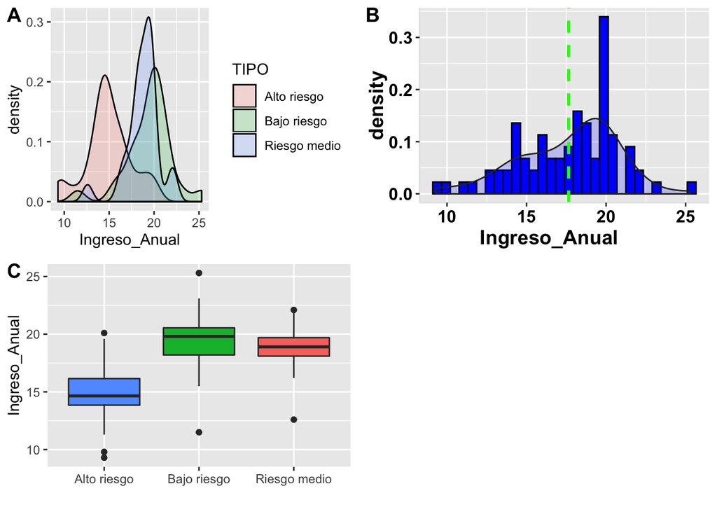

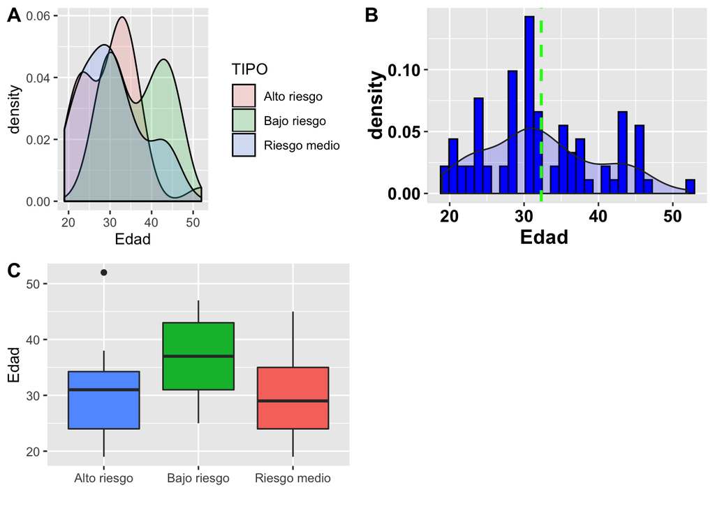

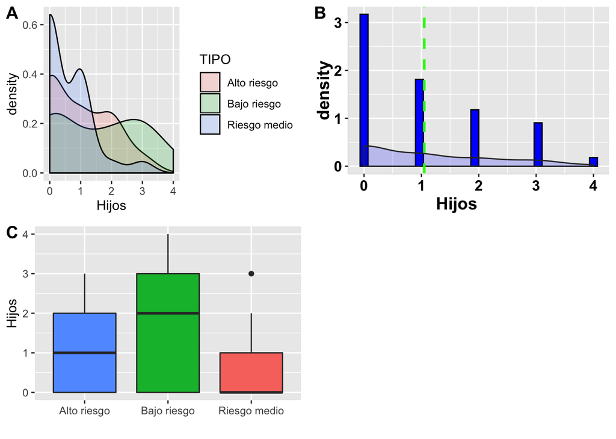

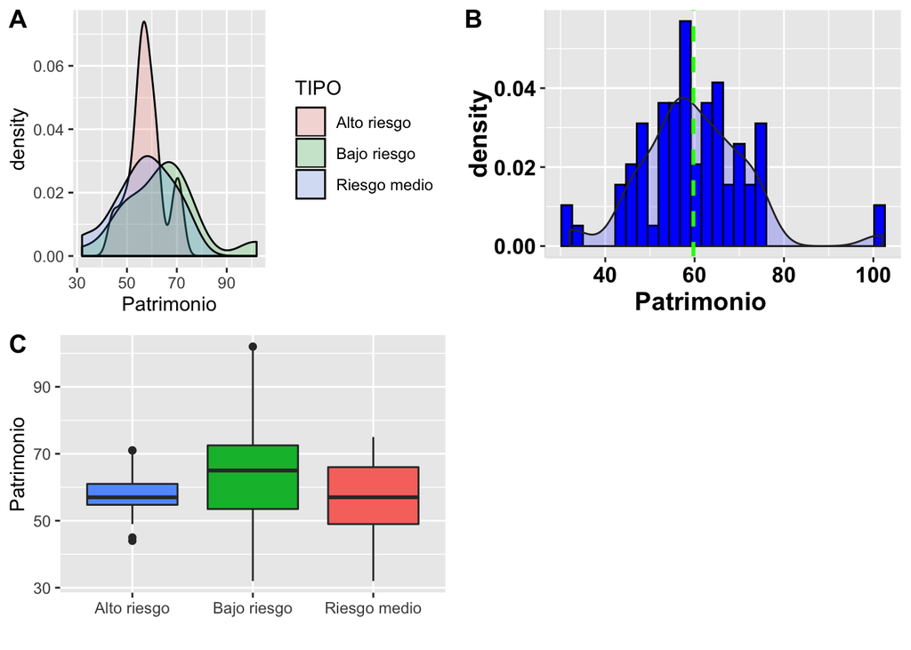

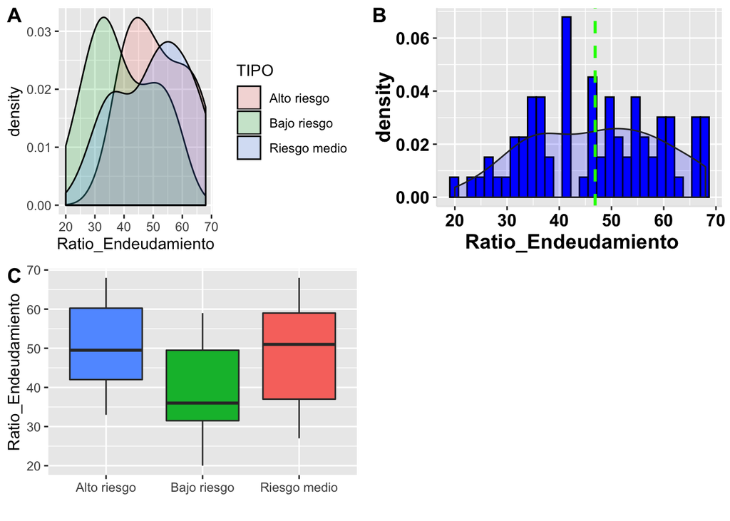

### CORRELATION MATRIX OF NUMERIC VARIABLES

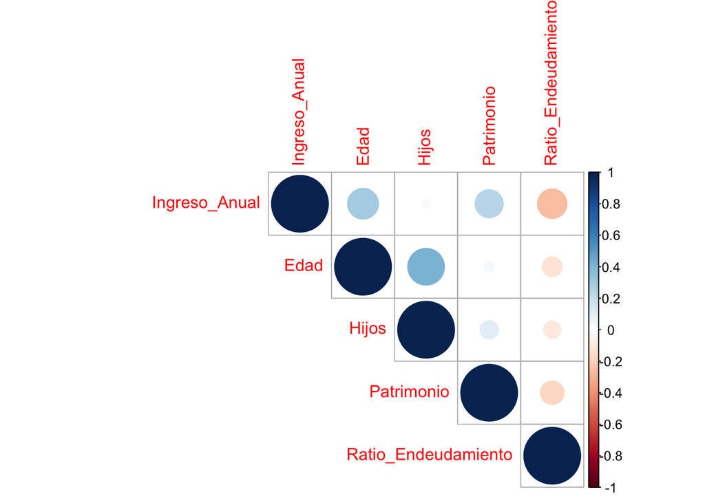

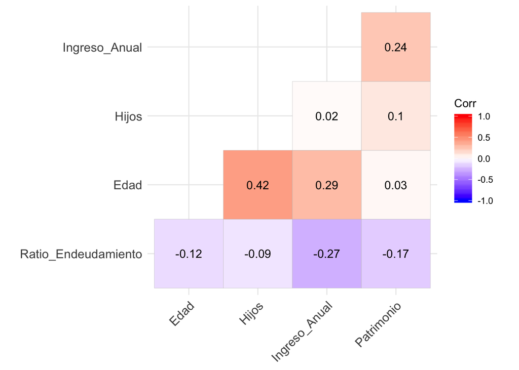

```
##                     Ingreso_Anual  Edad Hijos Patrimonio
## Ingreso_Anual                1.00  0.29  0.02       0.24
## Edad                         0.29  1.00  0.42       0.03
## Hijos                        0.02  0.42  1.00       0.10
## Patrimonio                   0.24  0.03  0.10       1.00
## Ratio_Endeudamiento         -0.27 -0.12 -0.09      -0.17
##                     Ratio_Endeudamiento
## Ingreso_Anual                     -0.27
## Edad                              -0.12
## Hijos                             -0.09
## Patrimonio                        -0.17
## Ratio_Endeudamiento                1.00
```

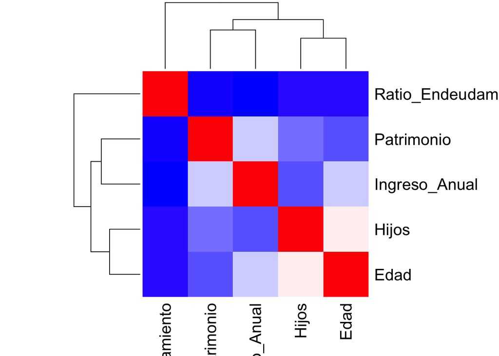

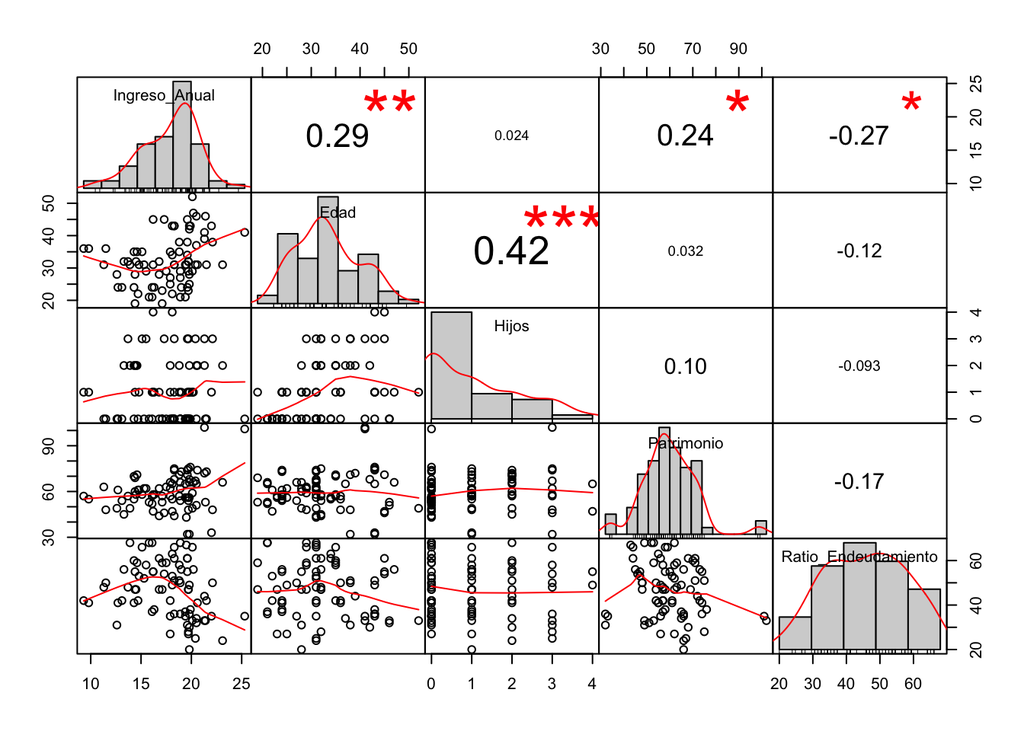

## CATEGORICAL VARIABLES:

- TIPO
- Aversion_Riesgo
- Estado_Civil
- Sexo

### HISTOGRAMS

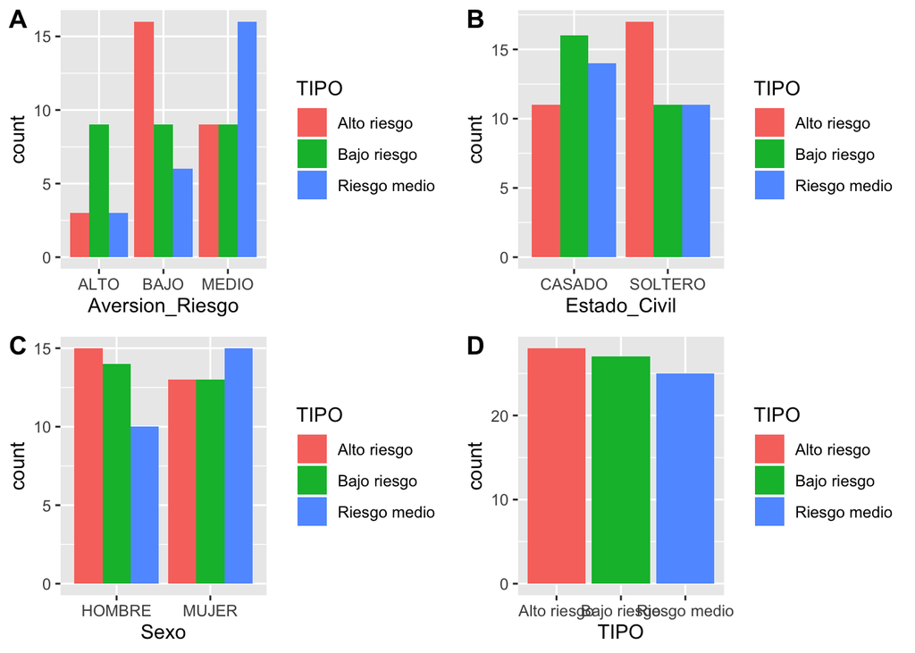

### RELATIONSHIPS BETWEEN VARIABLES

```
##
##                 ALTO  BAJO MEDIO
##   Alto riesgo   3.75 20.00 11.25
##   Bajo riesgo  11.25 11.25 11.25
##   Riesgo medio  3.75  7.50 20.00
```

```
##
##                CASADO SOLTERO
##   Alto riesgo   13.75   21.25
##   Bajo riesgo   20.00   13.75
##   Riesgo medio  17.50   13.75
```

```
##
##                HOMBRE MUJER
##   Alto riesgo   18.75 16.25
##   Bajo riesgo   17.50 16.25
##   Riesgo medio  12.50 18.75
```

# TESTING NORMALITY

In oder to apply the following models we would need normality in our variable’s distributions. We study normality in our whole variable and then separated by Type. In the following code we can see which ones follow a normal distribution and which ones don’t.

```r
############
# NORMALITY###########################################################################
############
# Testing normality of the numeric variables.
# From the output, the p-value > 0.05 implying that the distribution of the data are not significantly different from normal distribution. In other words, we can assume the normality.

# All sample together
shapiro.test(df$Ingreso_Anual)
```

```
##
##  Shapiro-Wilk normality test
##
## data:  df$Ingreso_Anual
## W = 0.96695, p-value = 0.03633
```

```r
shapiro.test(df$Edad)
```

```
##
##  Shapiro-Wilk normality test
##
## data:  df$Edad
## W = 0.96417, p-value = 0.02431
```

```r
shapiro.test(df$Patrimonio)
```

```
##
##  Shapiro-Wilk normality test
##
## data:  df$Patrimonio
## W = 0.94578, p-value = 0.001992
```

```r
shapiro.test(df$Ratio_Endeudamiento) # normal as p-value> 0.05
```

```
##
##  Shapiro-Wilk normality test
##
## data:  df$Ratio_Endeudamiento
## W = 0.97202, p-value = 0.07633
```

```r
shapiro.test(df$Hijos)
```

```
##
##  Shapiro-Wilk normality test
##
## data:  df$Hijos
## W = 0.81833, p-value = 1.612e-08
```

```r
# All sample together
shapiro.test(filter(df, TIPO == "Bajo riesgo")$Ingreso_Anual)# normal
```

```
##
##  Shapiro-Wilk normality test
##
## data:  filter(df, TIPO == "Bajo riesgo")$Ingreso_Anual
## W = 0.92551, p-value = 0.05369
```

```r
shapiro.test(filter(df, TIPO == "Riesgo medio")$Ingreso_Anual)
```

```
##
##  Shapiro-Wilk normality test
##
## data:  filter(df, TIPO == "Riesgo medio")$Ingreso_Anual
## W = 0.88465, p-value = 0.008632
```

```r
shapiro.test(filter(df, TIPO == "Alto riesgo")$Ingreso_Anual)# normal
```

```
##
##  Shapiro-Wilk normality test
##
## data:  filter(df, TIPO == "Alto riesgo")$Ingreso_Anual
## W = 0.96626, p-value = 0.4846
```

```r
shapiro.test(filter(df, TIPO == "Bajo riesgo")$Edad)
```

```
##
##  Shapiro-Wilk normality test
##
## data:  filter(df, TIPO == "Bajo riesgo")$Edad
## W = 0.90995, p-value = 0.02276
```

```r
shapiro.test(filter(df, TIPO == "Riesgo medio")$Edad)# normal
```

```
##
##  Shapiro-Wilk normality test
##
## data:  filter(df, TIPO == "Riesgo medio")$Edad
## W = 0.9346, p-value = 0.111
```

```r
shapiro.test(filter(df, TIPO == "Alto riesgo")$Edad)
```

```
##
##  Shapiro-Wilk normality test
##
## data:  filter(df, TIPO == "Alto riesgo")$Edad
## W = 0.9052, p-value = 0.01518
```

```r
shapiro.test(filter(df, TIPO == "Bajo riesgo")$Patrimonio)# normal
```

```
##
##  Shapiro-Wilk normality test
##
## data:  filter(df, TIPO == "Bajo riesgo")$Patrimonio
## W = 0.9327, p-value = 0.0805
```

```r
shapiro.test(filter(df, TIPO == "Riesgo medio")$Patrimonio)# normal
```

```
##
##  Shapiro-Wilk normality test
##
## data:  filter(df, TIPO == "Riesgo medio")$Patrimonio
## W = 0.96266, p-value = 0.47
```

```r
shapiro.test(filter(df, TIPO == "Alto riesgo")$Patrimonio)# normal
```

```
##
##  Shapiro-Wilk normality test
##
## data:  filter(df, TIPO == "Alto riesgo")$Patrimonio
## W = 0.95356, p-value = 0.2432
```

```r
shapiro.test(filter(df, TIPO == "Bajo riesgo")$Ratio_Endeudamiento)# normal
```

```
##
##  Shapiro-Wilk normality test
##
## data:  filter(df, TIPO == "Bajo riesgo")$Ratio_Endeudamiento
## W = 0.95138, p-value = 0.2316
```

```r
shapiro.test(filter(df, TIPO == "Riesgo medio")$Ratio_Endeudamiento)# normal
```

```
##
##  Shapiro-Wilk normality test
##
## data:  filter(df, TIPO == "Riesgo medio")$Ratio_Endeudamiento
## W = 0.94683, p-value = 0.2125
```

```r
shapiro.test(filter(df, TIPO == "Alto riesgo")$Ratio_Endeudamiento)# normal
```

```
##
##  Shapiro-Wilk normality test
##
## data:  filter(df, TIPO == "Alto riesgo")$Ratio_Endeudamiento
## W = 0.94676, p-value = 0.1641
```

```r
shapiro.test(filter(df, TIPO == "Bajo riesgo")$Hijos)
```

```
##
##  Shapiro-Wilk normality test
##
## data:  filter(df, TIPO == "Bajo riesgo")$Hijos
## W = 0.86166, p-value = 0.001977
```

```r
shapiro.test(filter(df, TIPO == "Riesgo medio")$Hijos)
```

```
##
##  Shapiro-Wilk normality test
##
## data:  filter(df, TIPO == "Riesgo medio")$Hijos
## W = 0.70997, p-value = 9.955e-06
```

```r
shapiro.test(filter(df, TIPO == "Alto riesgo")$Hijos)
```

```
##
##  Shapiro-Wilk normality test
##
## data:  filter(df, TIPO == "Alto riesgo")$Hijos
## W = 0.82273, p-value = 0.000276
```

# **b) Apply a discriminant analysis to this case justifying the selection of discriminant variables. Interpret the discriminant function and evaluate the importance of each of the discriminant variables. Evaluate the predictive capacity of the model.**

# DISCRIMINANT ANALYSIS WITH IMPORTANT VARIABLES

We first need to encode the categorical variables to work with them in order to create the models.

We descriminate between important and less important variables based on their discriminatory power (based on the distance between means of their corresponding distribution). In the following code we can see which ones have no significant mean difference. So they have less predictive power.

```r
#################################################
# DISCRIMINANT ANALYSIS WITH IMPORTANT VARIABLES#
#################################################
# We descriminate between important and less important variables based on their discriminatory power (based on the distance between means of their corresponding distribution).

######################
# IMPORTANT VARIABLES#
######################
# p-value>0.05, we accept null hypotehsis: true difference in means is equal to 0.#no significant mean difference
t.test(filter(df, TIPO == "Bajo riesgo")$Ratio_Endeudamiento,filter(df, TIPO == "Riesgo medio")$Ratio_Endeudamiento)
```

```
##
##  Welch Two Sample t-test
##
## data:  filter(df, TIPO == "Bajo riesgo")$Ratio_Endeudamiento and filter(df, TIPO == "Riesgo medio")$Ratio_Endeudamiento
## t = -3.1827, df = 48.854, p-value = 0.002538
## alternative hypothesis: true difference in means is not equal to 0
## 95 percent confidence interval:
##  -17.029899  -3.847138
## sample estimates:
## mean of x mean of y
##  39.48148  49.92000
```

```r
t.test(filter(df, TIPO == "Riesgo medio")$Ratio_Endeudamiento,filter(df, TIPO == "Alto riesgo")$Ratio_Endeudamiento)#no significant mean difference
```

```
##
##  Welch Two Sample t-test
##
## data:  filter(df, TIPO == "Riesgo medio")$Ratio_Endeudamiento and filter(df, TIPO == "Alto riesgo")$Ratio_Endeudamiento
## t = -0.42371, df = 47.428, p-value = 0.6737
## alternative hypothesis: true difference in means is not equal to 0
## 95 percent confidence interval:
##  -7.643288  4.983288
## sample estimates:
## mean of x mean of y
##     49.92     51.25
```

```r
t.test(filter(df, TIPO == "Bajo riesgo")$Ratio_Endeudamiento,filter(df, TIPO == "Alto riesgo")$Ratio_Endeudamiento)
```

```
##
##  Welch Two Sample t-test
##
## data:  filter(df, TIPO == "Bajo riesgo")$Ratio_Endeudamiento and filter(df, TIPO == "Alto riesgo")$Ratio_Endeudamiento
## t = -4.0044, df = 52.204, p-value = 0.0001977
## alternative hypothesis: true difference in means is not equal to 0
## 95 percent confidence interval:
##  -17.665266  -5.871771
## sample estimates:
## mean of x mean of y
##  39.48148  51.25000
```

```r
t.test(filter(df, TIPO == "Bajo riesgo")$Ingreso_Anual,filter(df, TIPO == "Riesgo medio")$Ingreso_Anual)#no significant mean difference
```

```
##
##  Welch Two Sample t-test
##
## data:  filter(df, TIPO == "Bajo riesgo")$Ingreso_Anual and filter(df, TIPO == "Riesgo medio")$Ingreso_Anual
## t = 1.1558, df = 47.387, p-value = 0.2536
## alternative hypothesis: true difference in means is not equal to 0
## 95 percent confidence interval:
##  -0.529881  1.961585
## sample estimates:
## mean of x mean of y
##  19.45185  18.73600
```

```r
t.test(filter(df, TIPO == "Riesgo medio")$Ingreso_Anual,filter(df, TIPO == "Alto riesgo")$Ingreso_Anual)
```

```
##
##  Welch Two Sample t-test
##
## data:  filter(df, TIPO == "Riesgo medio")$Ingreso_Anual and filter(df, TIPO == "Alto riesgo")$Ingreso_Anual
## t = 6.2504, df = 49.27, p-value = 9.419e-08
## alternative hypothesis: true difference in means is not equal to 0
## 95 percent confidence interval:
##  2.576193 5.017235
## sample estimates:
## mean of x mean of y
##  18.73600  14.93929
```

```r
t.test(filter(df, TIPO == "Bajo riesgo")$Ingreso_Anual,filter(df, TIPO == "Alto riesgo")$Ingreso_Anual)
```

```
##
##  Welch Two Sample t-test
##
## data:  filter(df, TIPO == "Bajo riesgo")$Ingreso_Anual and filter(df, TIPO == "Alto riesgo")$Ingreso_Anual
## t = 6.5521, df = 52.869, p-value = 2.393e-08
## alternative hypothesis: true difference in means is not equal to 0
## 95 percent confidence interval:
##  3.131091 5.894041
## sample estimates:
## mean of x mean of y
##  19.45185  14.93929
```

```r
t.test(filter(df, TIPO == "Bajo riesgo")$Edad,filter(df, TIPO == "Riesgo medio")$Edad)
```

```
##
##  Welch Two Sample t-test
##
## data:  filter(df, TIPO == "Bajo riesgo")$Edad and filter(df, TIPO == "Riesgo medio")$Edad
## t = 3.0646, df = 48.885, p-value = 0.003543
## alternative hypothesis: true difference in means is not equal to 0
## 95 percent confidence interval:
##   2.133607 10.263430
## sample estimates:
## mean of x mean of y
##  36.51852  30.32000
```

```r
t.test(filter(df, TIPO == "Riesgo medio")$Edad,filter(df, TIPO == "Alto riesgo")$Edad)#no significant mean difference
```

```
##
##  Welch Two Sample t-test
##
## data:  filter(df, TIPO == "Riesgo medio")$Edad and filter(df, TIPO == "Alto riesgo")$Edad
## t = 0.14165, df = 49.267, p-value = 0.8879
## alternative hypothesis: true difference in means is not equal to 0
## 95 percent confidence interval:
##  -3.748176  4.316747
## sample estimates:
## mean of x mean of y
##  30.32000  30.03571
```

```r
t.test(filter(df, TIPO == "Bajo riesgo")$Edad,filter(df, TIPO == "Alto riesgo")$Edad)
```

```
##
##  Welch Two Sample t-test
##
## data:  filter(df, TIPO == "Bajo riesgo")$Edad and filter(df, TIPO == "Alto riesgo")$Edad
## t = 3.4292, df = 52.929, p-value = 0.00118
## alternative hypothesis: true difference in means is not equal to 0
## 95 percent confidence interval:
##   2.690837 10.274771
## sample estimates:
## mean of x mean of y
##  36.51852  30.03571
```

```r
###########################
# LESS IMPORTANT VARIABLES#
###########################
#No significance mean difference:

#At least 2 no significant mean differences between types of risk.
t.test(filter(df, TIPO == "Bajo riesgo")$Hijos,filter(df, TIPO == "Riesgo medio")$Hijos)
```

```
##
##  Welch Two Sample t-test
##
## data:  filter(df, TIPO == "Bajo riesgo")$Hijos and filter(df, TIPO == "Riesgo medio")$Hijos
## t = 3.3403, df = 41.065, p-value = 0.00179
## alternative hypothesis: true difference in means is not equal to 0
## 95 percent confidence interval:
##  0.4083142 1.6568710
## sample estimates:
## mean of x mean of y
##  1.592593  0.560000
```

```r
t.test(filter(df, TIPO == "Riesgo medio")$Hijos,filter(df, TIPO == "Alto riesgo")$Hijos)#no significant mean difference
```

```
##
##  Welch Two Sample t-test
##
## data:  filter(df, TIPO == "Riesgo medio")$Hijos and filter(df, TIPO == "Alto riesgo")$Hijos
## t = -1.6607, df = 49.949, p-value = 0.103
## alternative hypothesis: true difference in means is not equal to 0
## 95 percent confidence interval:
##  -0.89327818  0.08470675
## sample estimates:
## mean of x mean of y
## 0.5600000 0.9642857
```

```r
t.test(filter(df, TIPO == "Bajo riesgo")$Hijos,filter(df, TIPO == "Alto riesgo")$Hijos)#no significant mean difference
```

```
##
##  Welch Two Sample t-test
##
## data:  filter(df, TIPO == "Bajo riesgo")$Hijos and filter(df, TIPO == "Alto riesgo")$Hijos
## t = 1.9152, df = 47.034, p-value = 0.06156
## alternative hypothesis: true difference in means is not equal to 0
## 95 percent confidence interval:
##  -0.03167489  1.28828865
## sample estimates:
## mean of x mean of y
## 1.5925926 0.9642857
```

```r
t.test(filter(df, TIPO == "Bajo riesgo")$Patrimonio,filter(df, TIPO == "Riesgo medio")$Patrimonio)#no significant mean difference
```

```
##
##  Welch Two Sample t-test
##
## data:  filter(df, TIPO == "Bajo riesgo")$Patrimonio and filter(df, TIPO == "Riesgo medio")$Patrimonio
## t = 1.8678, df = 48.394, p-value = 0.06786
## alternative hypothesis: true difference in means is not equal to 0
## 95 percent confidence interval:
##  -0.5360508 14.5923471
## sample estimates:
## mean of x mean of y
##  64.14815  57.12000
```

```r
t.test(filter(df, TIPO == "Riesgo medio")$Patrimonio,filter(df, TIPO == "Alto riesgo")$Patrimonio)#no significant mean difference
```

```
##
##  Welch Two Sample t-test
##
## data:  filter(df, TIPO == "Riesgo medio")$Patrimonio and filter(df, TIPO == "Alto riesgo")$Patrimonio
## t = -0.24734, df = 38.148, p-value = 0.806
## alternative hypothesis: true difference in means is not equal to 0
## 95 percent confidence interval:
##  -6.113661  4.782233
## sample estimates:
## mean of x mean of y
##  57.12000  57.78571
```

```r
t.test(filter(df, TIPO == "Bajo riesgo")$Patrimonio,filter(df, TIPO == "Alto riesgo")$Patrimonio)#no significant mean difference
```

```
##
##  Welch Two Sample t-test
##
## data:  filter(df, TIPO == "Bajo riesgo")$Patrimonio and filter(df, TIPO == "Alto riesgo")$Patrimonio
## t = 1.974, df = 36.084, p-value = 0.05607
## alternative hypothesis: true difference in means is not equal to 0
## 95 percent confidence interval:
##  -0.1736602 12.8985279
## sample estimates:
## mean of x mean of y
##  64.14815  57.78571
```

We create a model with the variables that allow us to differentiate more each group of risk based on their distribution. The variables with more significance are: Ratio_Endeudamiento, Ingreso_Anual and Edad.

## DISCRIMINANT ANALYSIS WITH HIGHEST PREDICTIVE POWER BASED ON THEIR MEAN DIFFERENCE

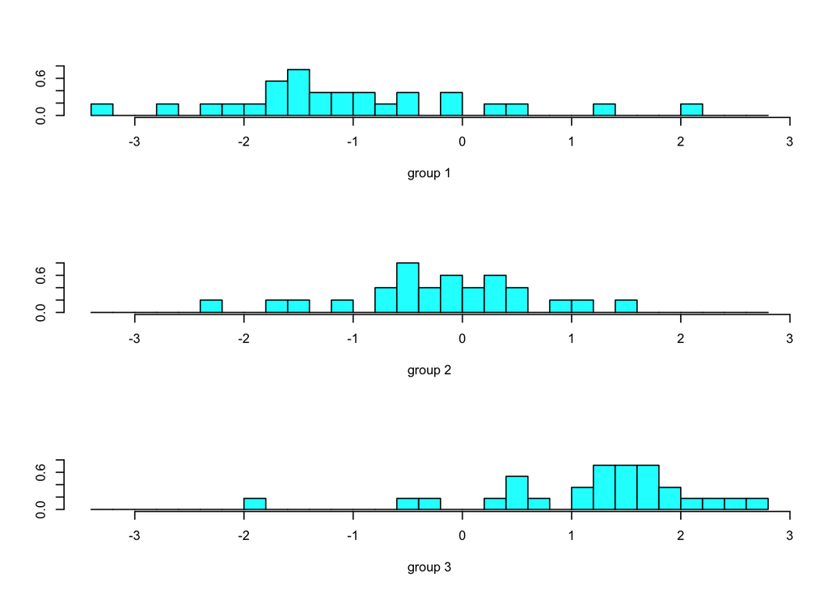

```r
##################################################
# DISCRIMINANT ANALYSIS WITH IMPORTANT  VARIABLES#
##################################################
df.lda <- lda(TIPO ~ Ratio_Endeudamiento + Ingreso_Anual + Edad  , data=df_wrangling)
df.lda.values <- predict(df.lda)

ldahist(data = df.lda.values$x[,1], g=df_wrangling$TIPO)
```

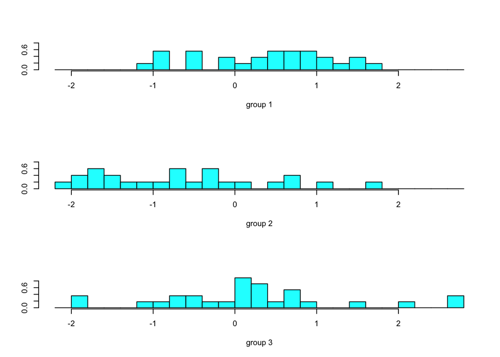

```r
ldahist(data = df.lda.values$x[,2], g=df_wrangling$TIPO)
```

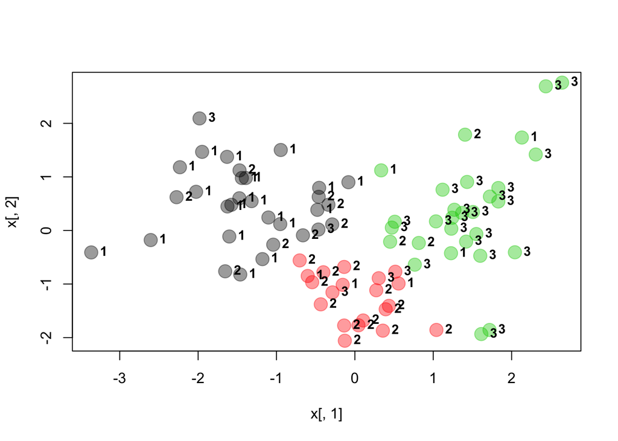

```
## integer(0)
```

```r
plot(x[,2]~x[,1], col=addTrans(class,100), pch=19, cex=2,data=df.lda.values)+
text(x[,2]~x[,1], labels=df_wrangling$TIPO,data=df.lda.values, cex=0.9, font=2, pos=4)
```

```r
table(predict(df.lda)$class, df_wrangling$TIPO)
```

```
##
##      1  2  3
##   1 21  8  2
##   2  3 14  3
##   3  3  3 23
```

```r
confusion_matrix <- table(df.lda.values$class, df_wrangling$TIPO)
confusion_matrix
```

```
##
##      1  2  3
##   1 21  8  2
##   2  3 14  3
##   3  3  3 23
```

```r
precision <- sum(diag(confusion_matrix))/sum(confusion_matrix)
cat("Predictive capacity of the model. Precision:", precision)
```

```
## Predictive capacity of the model. Precision: 0.725
```

Predictive capacity of the model. Precision: 0.725

# DISCRIMINANT ANALYSIS WITH ALL VARIABLES

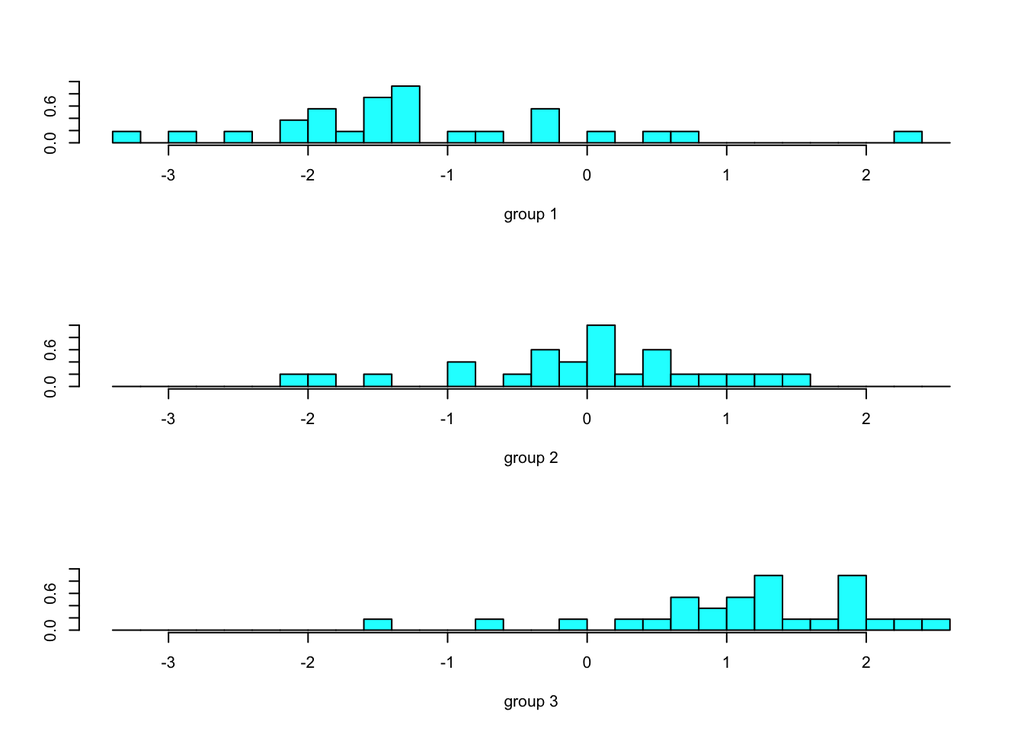

```r
###########################################
# DISCRIMINANT ANALYSIS WITH ALL VARIABLES#
###########################################
df.lda <- lda(TIPO ~ ., data=df_wrangling)
df.lda.values <- predict(df.lda)

ldahist(data = df.lda.values$x[,1], g=df_wrangling$TIPO)
```

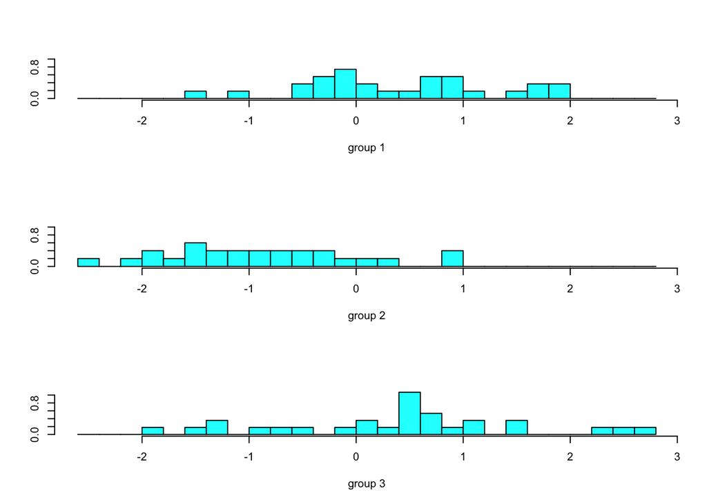

```r
ldahist(data = df.lda.values$x[,2], g=df_wrangling$TIPO)
```

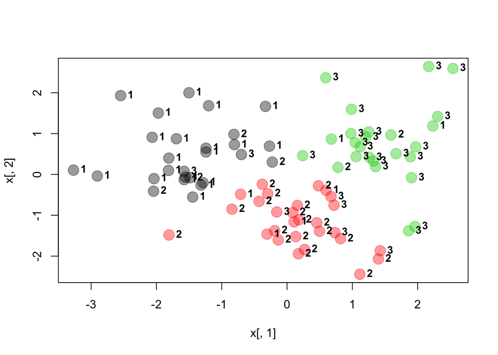

```
## integer(0)
```

```r
plot(x[,2]~x[,1], col=addTrans(class,100), pch=19, cex=2,data=df.lda.values)+
text(x[,2]~x[,1], labels=df_wrangling$TIPO,data=df.lda.values, cex=0.9, font=2, pos=4)
```

```r
# plot(df.lda.values$x[,1],df.lda.values$x[,2])+ # Hacer el scatterplot
# text(df.lda.values$x[,1],df.lda.values$x[,2],df_wrangling$TIPO,cex=0.7,pos=4,col="red") # a?adir etiquetas

table(predict(df.lda)$class, df_wrangling$TIPO)
```

```
##
##      1  2  3
##   1 21  4  2
##   2  4 19  5
##   3  2  2 21
```

```r
predict(df.lda,newdata=data.frame(Ingreso_Anual=19,Edad=28, Sexo=1,Estado_Civil=0, Hijos=1, Patrimonio=10,
                                    Ratio_Endeudamiento=34,Aversion_Riesgo=2))$class
```

```
## [1] 2
## Levels: 1 2 3
```

```r
confusion_matrix <- table(df.lda.values$class, df_wrangling$TIPO)
precision <- sum(diag(confusion_matrix))/sum(confusion_matrix)
confusion_matrix
```

```
##
##      1  2  3
##   1 21  4  2
##   2  4 19  5
##   3  2  2 21
```

```r
cat("Predictive capacity of the model. Precision:", precision)
```

```
## Predictive capacity of the model. Precision: 0.7625
```

The model with all variables has more predictive power (Precision of 0.7625) than the model with the filtered variables (based on their mean difference). The predictive capacity of the model with less variables was 0.725.

The first function created maximizes the differences between groups on that function. The second function maximizes differences on that function, but also must not be correlated with the previous function.

```
##                              LD1         LD2
## Ingreso_Anual       -0.343539464 -0.23462471
## Edad                -0.028699515  0.05447060
## Sexo                -0.175838268  0.19989166
## Estado_Civil        -0.298712225  0.75513055
## Hijos               -0.291974557  0.51307303
## Patrimonio          -0.005867184  0.03465300
## Ratio_Endeudamiento  0.034806402 -0.03371295
## Aversion_Riesgo      0.019862060 -0.12749812
```

Discriminant analysis works by creating one or more linear combinations of predictors, creating a new latent variable for each function. These functions are called discriminant functions. The number of functions possible is either Ng-1 where Ng = number of groups, or p (the number of predictors), whichever is smaller.

This model, automatically normalizes our variables to a standard normal distribution, so we can compare the significance of each of the discriminant variables. However, our variables are not normal. So we are ignoring one of the main hypotheses of this model. Ordered from more important to less important variables in the model, these are the results for the first function:

|  | sort(abs(df.lda$scaling[, 1]), decreasing = TRUE) |
| --- | --- |
| Ingreso_Anual | 0.343539464 |
| Estado_Civil | 0.298712225 |
| Hijos | 0.291974557 |
| Sexo | 0.175838268 |
| Ratio_Endeudamiento | 0.034806402 |
| Edad | 0.028699515 |
| Aversion_Riesgo | 0.019862060 |
| Patrimonio | 0.005867184 |

Ordered from more important to less important variables in the model, these are the results for the second function:

|  | sort(abs(df.lda$scaling[, 2]), decreasing = TRUE) |
| --- | --- |
| Estado_Civil | 0.75513055 |
| Hijos | 0.51307303 |
| Ingreso_Anual | 0.23462471 |
| Sexo | 0.19989166 |
| Aversion_Riesgo | 0.12749812 |
| Edad | 0.05447060 |
| Patrimonio | 0.03465300 |
| Ratio_Endeudamiento | 0.03371295 |

# **c) Apply a classification tree to this case justifying the selection of predictor variables, using a sample of 80% for the estimate and 20% for the validation sample (seed = 1234). Interpret the tree or trees and evaluate the importance of each of the predictor variables. Evaluate the predictive capacity of the model.**

# DECISION TREE MODEL

Based on xerror, we don’t prune this tree. And that’s reasonable as we already have a few nodes.

```r
# Semilla aleatoria
set.seed(1234)
# Definimos una muestra aleatoria de aprendizaje del arbol
train <- sample(nrow(df), 0.8*nrow(df))

# Data frame para la muestra de aprendizaje y otro para la muestra de validaci?n
df.train <- df[train,]
df.validate <- df[-train,]

# Vemos la distribucion de ambas muestras y comprobamos que est?n balanceadas
table(df.train$TIPO)
```

```
##
##  Alto riesgo  Bajo riesgo Riesgo medio
##           23           20           21
```

```r
table(df.validate$TIPO)
```

```
##
##  Alto riesgo  Bajo riesgo Riesgo medio
##            5            7            4
```

```r
# Cargamos la libreria rpart
library(rpart)
# Estimamos el arbol
arbol <- rpart(TIPO ~ ., data=df.train, method="class",
               parms=list(split="information"))
# summary(arbol)
# Tabla de complejidad param?trica
arbol$cptable
```

```
##           CP nsplit rel error    xerror       xstd
## 1 0.36585366      0 1.0000000 1.2439024 0.07850240
## 2 0.17073171      1 0.6341463 0.9024390 0.09636269
## 3 0.04878049      2 0.4634146 0.7804878 0.09756098
## 4 0.01000000      4 0.3658537 0.6097561 0.09519814
```

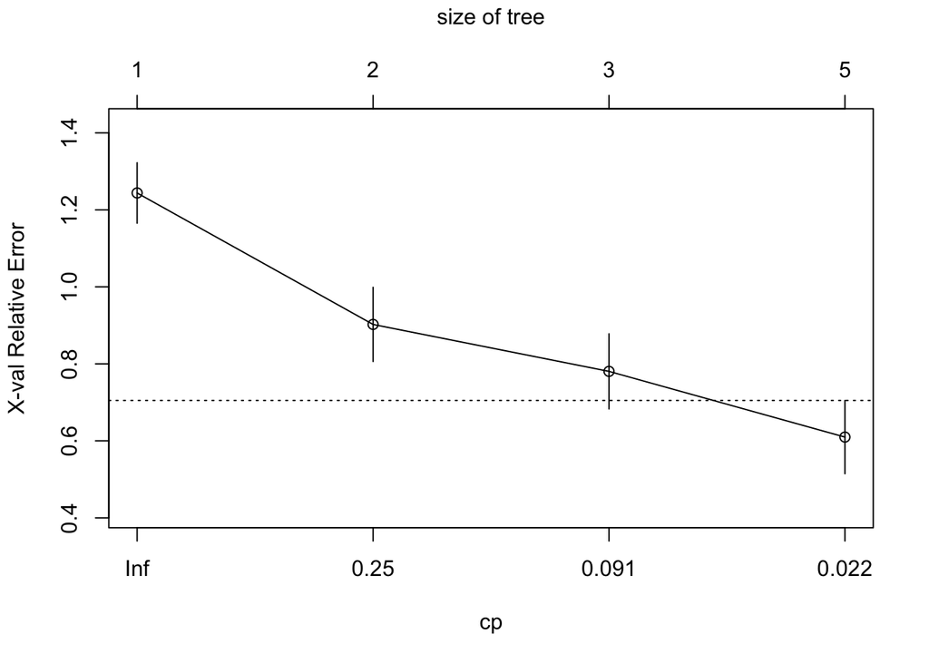

```r
# Representamos gr?ficamente la curva cp
plotcp(arbol)
```

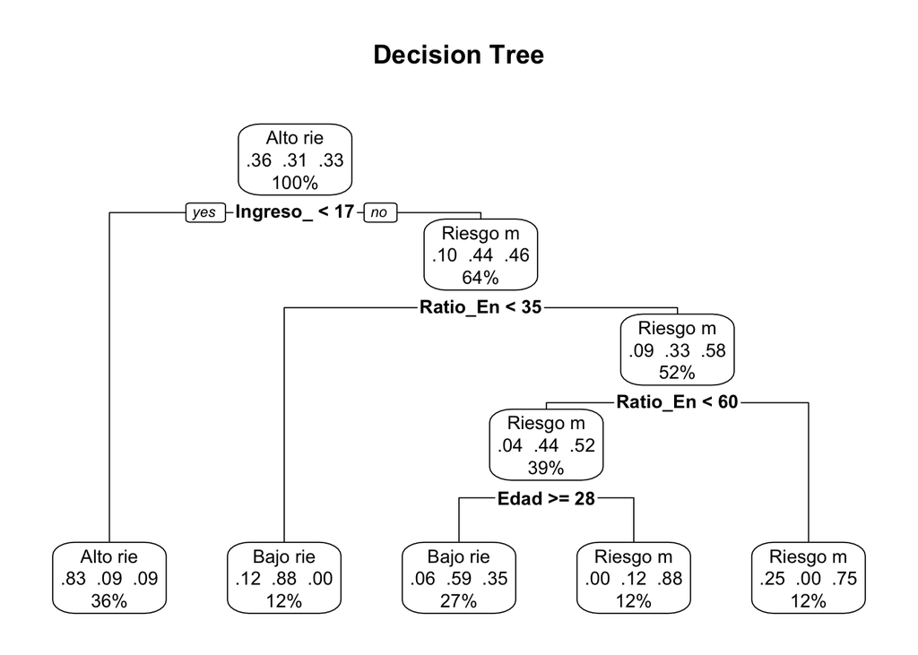

```
##               Predicted
## Actual         Alto riesgo Bajo riesgo Riesgo medio
##   Alto riesgo            4           0            1
##   Bajo riesgo            1           6            0
##   Riesgo medio           1           2            1
```

```
## Predictive capacity of the model. Precision: 0.6875
```

```r
# Podamos el arbol a partir del p?rametro de complejidad
arbol.podado <- prune(arbol, cp=0.01 )
# Cargamos la librer?a para representar graficamente el ?rbol
library(rpart.plot)
prp(arbol.podado, type = 2, extra = 104,
    fallen.leaves = TRUE, main="Decision Tree")
```

This model has less predictive power (Precision: 0.6875)than the discriminant analysis model (Precision: 0.7625).

The most important variables in the tree model are the following:

|  | sort(abs(arbol$variable.importance), decreasing = TRUE) |
| --- | --- |
| Ingreso_Anual | 18.062851 |
| Ratio_Endeudamiento | 12.465920 |
| Edad | 7.979281 |
| Aversion_Riesgo | 3.926707 |
| Hijos | 1.255622 |